# **MA415 Midterm Project: Safety in the workplace in Massachusetts**

Making data ready for analysis

Sarah Gore- U72145380

This version: March 22, 2017

Available versions of this document: [html–notebook version](http://htmlpreview.github.com/?https://github.com/sezzagore/Midterm/blob/master/Midterm_Project.nb.html), [pdf version](https://github.com/sezzagore/Midterm/blob/master/Midterm_Project.pdf), [R script alone](https://github.com/sezzagore/Midterm/blob/master/Midterm_Project.R), [html with full code version](http://htmlpreview.github.com/?https://github.com/sezzagore/Midterm/blob/master/Midterm_Project.html). These files can be found on my [GitHub](https://github.com/sezzagore/Midterm).

# General purpose

## Driving Question and Present Contribution

What is the safest workplace in MA and what can the data provided tell us about it?

I am cleaning the data provided in order to get it ready for analysis. Through doing this, I exclude data that I think is unnecessary,but at the same time I justify (to a certain extent) how and why this is done. This work is the important step between the data collection and data analysis.

This project will only focus on the second of the following steps in a data project:

1. Data collection
2. **Data cleaning**
3. Analysis

I acknowledge that there are many different ways to perform this project. I believe however, that this will prove useful.

# Data

## Source

The data was collected by [OSHA](https://www.osha.gov/oshstats/index.html) and provided by [NICAR](http://www.ire.org/nicar/).

The data provided covers the period 01/1972- 02/2006. It contains various tables ranging from the time that the inspections were carried out, accidents incurred, body parts injured, violations, fines etc…

The main data table is OSHA and the various supplementary tables provide key information for specific issues with the inspection such as accidents or violations, for example. There are also look-up tables that provide further sources of information about the coding for instance.

The links between the various data files can be made more clear by consulting the following [file](https://ire.org/media/uploads/files/datalibrary/samplefiles/OSHA%20Workplace%20Safety%20Data/osha.pdf).

For more information about the variables used in the data, click on the following [file](http://ire.org/media/uploads/files/datalibrary/samplefiles/OSHA%20Workplace%20Safety%20Data/OSHA.txt).

# Tables under consideration

I will be using OSHA as it is our main source. Furthermore, I will be using ACCID as well as VIOL. In this project I am concerned with safety in the workplace and it seems reasonable to analyze data related to accidents and violations.

I have excluded potentially useful data, such as company debt. However given the abundance of data, I find it is more relevance to choose the variables that I have.

# Reading the data

```r
knitr::opts_chunk$set(echo = TRUE, tidy = TRUE, cache = TRUE)
require(ggplot2)
require(tidyr)
require(dplyr)
require(readr) # to read text
require(foreign) # library used to import the dbfs
require(lubridate) # library used for dates/times
```

First I load the relevant libraries that I use in the cleaning process. As mentioned above, I am working with three files, `osha`, `accid` and `viol`. In order to simplify the cleaning process and upcoming analysis, I am going to merge them into one file.

```r
# read the data and transform in tibble (for speed and better behaviour of the data frame)
osha <-  read.dbf("osha.dbf", as.is = TRUE) %>%
  tbl_df
accid <- read.dbf("accid.dbf", as.is = TRUE) %>%
  tbl_df
viol <- read.dbf("viol.dbf", as.is = TRUE) %>%
  tbl_df
join_1 <- left_join(osha, accid, by = "ACTIVITYNO")
osha <- left_join(join_1, viol, by = "ACTIVITYNO")
rm(list = setdiff(ls(), "osha")) # I erase my environment and now only have osha in my environment
```

I merge the three variables into one larger data frame and call it `osha`. This file contains all the information that was in `osha`, `accid` and `viol`.

However, after careful consideration, I realized that this goes against the principles of tidy data. So, I keep the three data frames separated.

```r
osha <-  read.dbf("osha.dbf", as.is = TRUE) %>%
  tbl_df
accid <- read.dbf("accid.dbf", as.is = TRUE) %>%
  tbl_df
viol <- read.dbf("viol.dbf", as.is = TRUE) %>%
  tbl_df
```

## Some notes on the data

# Removing variables

At this stage I want to remove some unnecessary variables. I explain below which variables I remove and the reason for doing so.

## Single value variables

Single value variables are vectors that contain only one unique value or one value and `NA’s. In order to simplify the data sets, I remove these variables from the data frames.

For that purpose I wrote a specific function: `clean.from.one.value()`. This function takes a data frame as input and returns the same data frame without these variables.

```r
clean.from.one.value <- function(df){
  if(!is.data.frame(df)){
    print("Not executed: the function requires a data frame object.")
    return()
  }
  one.value <- function(vec){length(unique(vec))==1}
  clean.df <- df[,!sapply(df, one.value)]
  if(length(df)-length(clean.df)==0) {
    print("No variable removed.")
  } else {print(paste(length(df)-length(clean.df),"variables removed:",  length(df),"->",length(clean.df) ))
    }
  return(clean.df)
}
```

I now apply the function defined above to my three data frames.

```r
osha <- clean.from.one.value(osha)
```

```
[1] "8 variables removed: 92 -> 84"
```

```r
accid <- clean.from.one.value(accid)
```

```
[1] "1 variables removed: 16 -> 15"
```

```r
viol <- clean.from.one.value(viol)
```

```
[1] "3 variables removed: 48 -> 45"
```

## Irrelevant variables in `osha`

Here I make a choice of variables that I think are unnecessary and can therefore be removed.

### NICAR dates

NICAR converted the original dates into a standard format. Therefore, I discard the original variables that contain the original dates.

```r
irrelavant_variables <- c("OSHA1MOD", "OPENDATE", "CLOSEDATE", "CLOSEDATE2",  "FRSTDENYN", "LSTREENTRN",
 "PENDUDATE", "FTADUDATE", "FRSTCONTST")
osha <- osha[,!(names(osha) %in% irrelavant_variables)]
rm(irrelavant_variables)
```

### Number of records

`osha` contains variables indicating counts in tables that I have discarded for this project. Therefore, I discard the variables relating to these tables.

```r
irrelavant_variables <- c("PROG_", "RELACT_","OPTINFO_", "DEBT_", "EVENT_", "HAZSUB_", "ADMPAY_")
osha <- osha[,!(names(osha) %in% irrelavant_variables)]
rm(irrelavant_variables)
```

### Paperwork times

Time spent on preparation, traveling, researching etc… are variables that I think are not going to be relevant in the analysis.

```r
irrelavant_variables <- c("PAPREP" ,"PATRAVEL" ,"PAONSITE", "PATECHSUPP" ,"PARPTPREP","PAOTHRCNF","PALITIGTN","PADENIAL" ,"PASUMHOURS")
osha <- osha[,!(names(osha) %in% irrelavant_variables)]
rm(irrelavant_variables)
```

### Debt-related variables

Since I have discarded the tables relating to debt, I can remove these variables from `osha`.

```r
irrelavant_variables <- c("PENDUDATE", "PENDUDT", "FTADUDATE", "FTADUDT", "DUECODE")
osha <- osha[,!(names(osha) %in% irrelavant_variables)]
rm(irrelavant_variables)
```

### Penalty- related variables

The same argument as mentioned in the previous point applies to this category.

```r
irrelavant_variables <- c("PENREMIT", "FTAREMIT", "TOTPENLTY", "TOTALFTA")
osha <- osha[,!(names(osha) %in% irrelavant_variables)]
rm(irrelavant_variables)
```

### Other irrelevant variables

This category applies to administrative information that I cannot use.

```r
irrelavant_variables <- c("DUNSNO", "HOSTESTKEY")
osha <- osha[,!(names(osha) %in% irrelavant_variables)]
rm(irrelavant_variables)
```

## Irrelevant variables in `accid`

### Unused categories

This subset applies to variables in `accid` that I discard.

```r
irrelavant_variables <- c("SITESTATE", "NAME", "RELINSP", "SOURCE", "ENVIRON", "EVENT", "TASK", "HAZSUB", "OCC_CODE")
accid <- accid[,!(names(accid) %in% irrelavant_variables)]
rm(irrelavant_variables)
```

## Irrelevant variables in `viol`

Again, I only use a subset of the variables in `viol` and discard the others. Here, the justification is that I don’t think that these variables are related to safety in the workplace, for instance abatement.

### Dates, citations and abatements etc…

```r
irrelavant_variables <- c("SITESTATE", "DELETE", "ISSUANCE", "ISSUEDATE", "CITATION", "ITEMNO", "ITEMGROUP", "EMPHASIS", "PENCURRENT", "PENINITIAL", "STD_LOOKUP", "STD", "ABATE", "DATE_ABATE", "ABATEDT", "ABATEDT2", "REC", "ABATEDONE")
viol <- viol[,!(names(viol) %in% irrelavant_variables)]
rm(irrelavant_variables)
```

### Violated Contested Information

```r
irrelavant_variables <- c("ERCONTDT", "ERCONDATE", "VIOLCONT", "PENCONT", "EMPRCONT", "EMPECONT", "FINORDT", "FINORDATE", "PMA", "AMENDED", "ISA", "DISPEVT" )
viol <- viol[,!(names(viol) %in% irrelavant_variables)]
rm(irrelavant_variables)
```

### Failure to abate

```r
irrelavant_variables <- c("FTAINSP", "FTAPEN", "ISSUDT", "FTA_ISDT", "CONTDT", "CONTDATE", "FTA_AMN", "FTA_ISA", "FTA_DISP", "FTA_FIN", "FTAFINDT", "HAZCAT")
viol <- viol[,!(names(viol) %in% irrelavant_variables)]
rm(irrelavant_variables)
```

# Adding information

In `osha` many variables come with coded-values; this is not very informative in particular when cleaning and graphing the data. In order to make the information more informative, I use the look-ups provided to add to translate the code to values I can use.

For instance, if I want to know about the places of inspections, I will use the name of the counties and I access these through the look-ups.

## New variables to `osha`

I added information about the place of inspection to `osha`. *(Notice that this method is drastically different from what was shown in class)*

```r
# I load the lookup from scc
scc <-  read.dbf("lookups/scc.dbf") %>%
  tbl_df %>%
  filter(STATE=="MA")
counties <-  read.dbf("lookups/scc.dbf") %>%
  tbl_df %>% filter(STATE=="MA") %>%
  filter(CITY == "0000", COUNTY!="000") %>%
  select(COUNTY, NAME) %>%
  rename(COUNTY_CODE =COUNTY, COUNTY_NAME= NAME)
osha <- left_join(osha,counties, by=c("SITECNTY"="COUNTY_CODE"))
cities <- read.dbf("lookups/scc.dbf") %>%
  tbl_df %>%
  filter(STATE=="MA") %>%
  filter(CITY != "0000", COUNTY!="000") %>%
  select(CITY, NAME) %>%
  rename(CITY_CODE =CITY, CITY_NAME= NAME)
osha <- left_join(osha,cities, by=c("SITECITY"="CITY_CODE"))
rm(scc, counties, cities)
```

## New variables to `accid`

I added information about the body- parts, nature of injury and human contribution in the accidents to `accid`.

```r
# I load the lookup from acc
acc <-  read.dbf("lookups/acc.dbf") %>%
  tbl_df %>%
  filter(CATEGORY=="PART-BODY") %>%
  rename(BODYPART_NAME = VALUE)
accid <- left_join(accid,acc, by=c("BODYPART"="CODE"))
acc <-  read.dbf("lookups/acc.dbf") %>%
  tbl_df %>%
  filter(CATEGORY=="NATURE-INJ") %>%
  rename(NATURE_NAME = VALUE)
accid <- left_join(accid,acc, by=c("NATURE"="CODE"))
acc <-  read.dbf("lookups/acc.dbf") %>%
  tbl_df %>%
  filter(CATEGORY=="HUMAN-FAC") %>%
  rename(HUMAN_NAME = VALUE)
accid <- left_join(accid,acc, by=c("HUMAN"="CODE"))
rm(acc)
```

# NA’s and missing values

Many variables contain NA’s. However there are various reasons for these NA’s. In some of the cases they do represent missing values. However, when going through the descriptions of the `osha` data, it became clear that some NA’s actually represent data and I want to account for that data.

## NA’s that represent actual data

Consider the following example taken from the description of the coding:

> WALKAROUND C 1 Employee representative present during inspection: B (blank) = no X = yes

Clearly, there is no information missing. The NA seen in the data represents the value “no”. Therefore in the variables that use this coding system, I replace the NA’s by “no”. My choice must be taken into account for future analyses.

```r
blank_variables <- c("CONTFLAG", "STFLAG", "PREVCTTYP", "WALKAROUND", "INTRVIEWD", "CLOSECASE", "SAFETYMANF", "SFTYCONST", "STFYMARIT", "HELTHMANF", "HELTHCONST", "HELTHMARIT", "MIGRANT", "ANTCSRVD")
blank_variables <- blank_variables[blank_variables %in% colnames(osha)]
osha[,blank_variables][is.na(osha[blank_variables])] <- "NO"
rm(blank_variables)
```

## Values that are actually NA’s

As a good practice, I plot the some of the data to look for outliers. Within the `accid` data under the age category, I encounter a bunch of zero’s which does not make sense; indeed as such a large number of zeros is an indication that something is wrong.

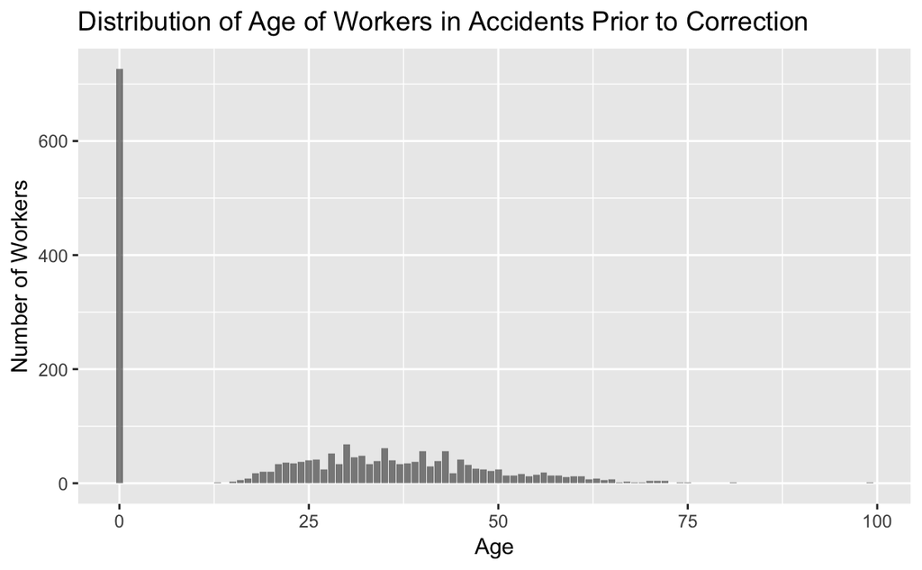

```r
accid %>%
  ggplot(aes(x = AGE)) +
  geom_bar(alpha = 0.7) +
  labs(title = "Distribution of Age of Workers in Accidents Prior to Correction", x = "Age", y = "Number of Workers")
```

I correct for this by specifically assigning the value NA to these zeros.

```r
accid$AGE[accid$AGE == 0] <- NA
```

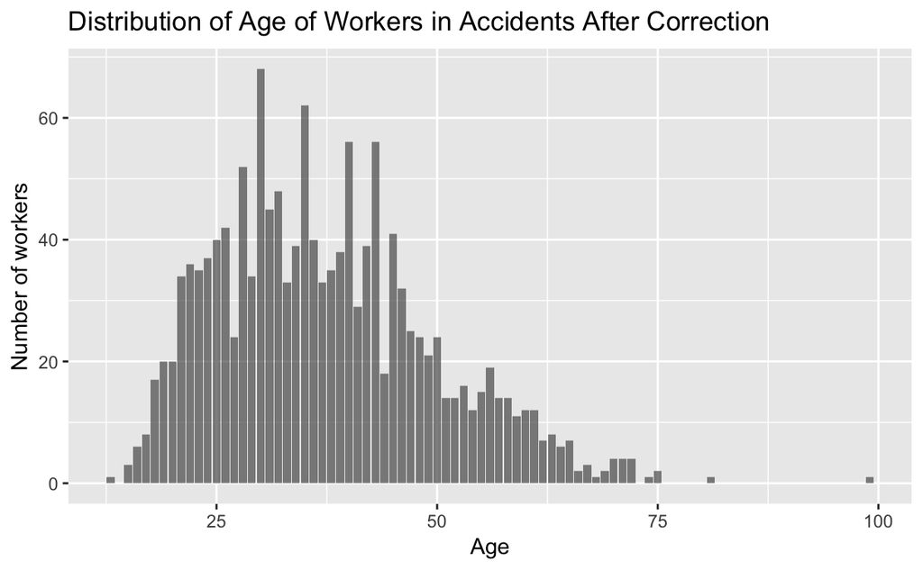

```r
accid %>%
  ggplot(aes(x = AGE)) +
  geom_bar(alpha = 0.7) +
  labs(title = "Distribution of Age of Workers in Accidents After Correction", x = "Age", y = "Number of workers")
```

# First glimpse at the data

There are very many ways of looking at the data that I have cleaned. Below are a few graphs that I feel give one a notion of the data.

## The number of accidents per county

Since, I am looking for secure work environment, a natural perspective would be to break-up accidents by county.

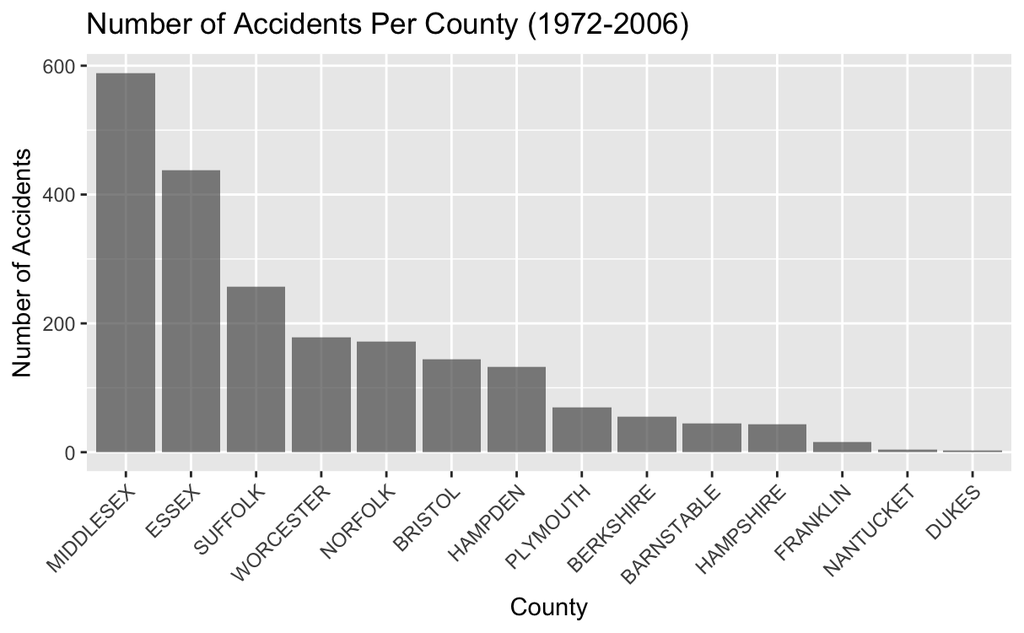

```r
osha %>%
  group_by(COUNTY_NAME) %>%
  summarise(accidents = sum(ACCID_)) %>%
  filter(!is.na(COUNTY_NAME)) %>%
  arrange(-accidents) %>%
  mutate(COUNTY_NAME = factor(COUNTY_NAME, COUNTY_NAME)) %>%
  ggplot(aes( x = COUNTY_NAME, y = accidents)) +
  geom_bar(alpha = 0.7, stat = "identity") +
  theme(axis.text.x = element_text(angle = 45, hjust = 1)) +
  labs(title = "Number of Accidents Per County (1972-2006)", x = "County", y = "Number of Accidents")
```

## The number of accidents per city

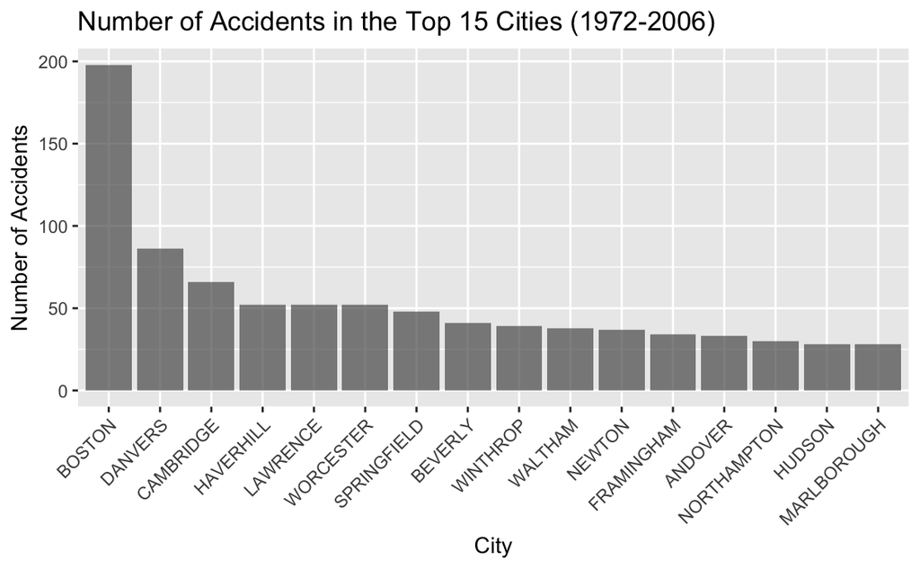

```r
osha %>%
  group_by(CITY_NAME) %>%
  summarise(accidents = sum(ACCID_)) %>%
  filter(!is.na(CITY_NAME)) %>%
  arrange(-accidents) %>%
  top_n(n = 15, accidents) %>%
  mutate(CITY_NAME = factor(CITY_NAME, CITY_NAME)) %>%
  ggplot(aes( x = CITY_NAME, y = accidents)) +
  geom_bar(alpha = 0.7, stat = "identity") +
  theme(axis.text.x = element_text(angle = 45, hjust = 1)) +
  labs(title = "Number of Accidents in the Top 15 Cities (1972-2006)", x = "City", y = "Number of Accidents")
```

## Accidents over time

I am interested in the evolution in the number of accidents over time. Here I plot the total number of accidents during that period in MA.

Notice that I exclude 1972 and 2006 because they are incomplete years.

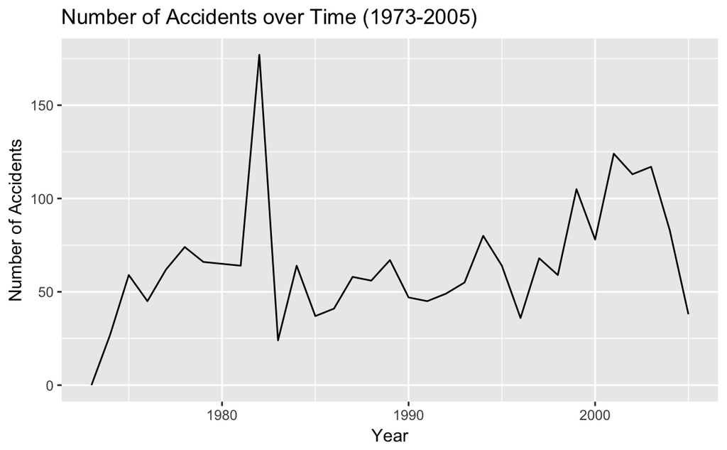

```r
osha %>%
  group_by(year(OPENDT)) %>%
  summarise(accidents = sum(ACCID_), year = mean(year(OPENDT))) %>%
  filter(year >1972, year < 2006) %>%
  ggplot(aes(x = year, y = accidents)) +
  geom_line() + labs(title = "Number of Accidents over Time (1973-2005)", x = "Year", y = "Number of Accidents")
```

I get further inside by breaking up the evolution over time by county.

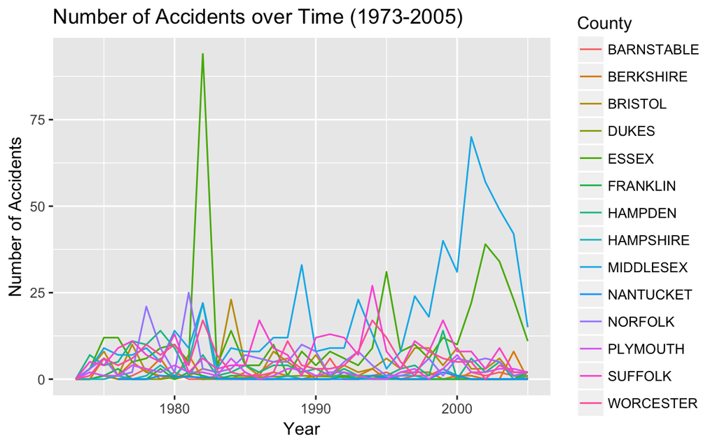

```r
osha %>%
  group_by(year(OPENDT), COUNTY_NAME) %>%
  filter(!is.na(COUNTY_NAME)) %>%
  summarise(accidents = sum(ACCID_), year = mean(year(OPENDT))) %>%
  filter(year >1972, year < 2006) %>%
  ggplot(aes(x = year, y = accidents, col = COUNTY_NAME, group = COUNTY_NAME)) +
  geom_line() +
  labs(title = "Number of Accidents over Time (1973-2005)", x = "Year", y = "Number of Accidents", col = "County" )
```

## Violations over time

Violations tell us how well firms are complying with the rules of safety. This is why evolution over time is informative. Here I plot the total number of violations during that period in MA.

Again I exclude 1972 and 2006 because they are incomplete years.

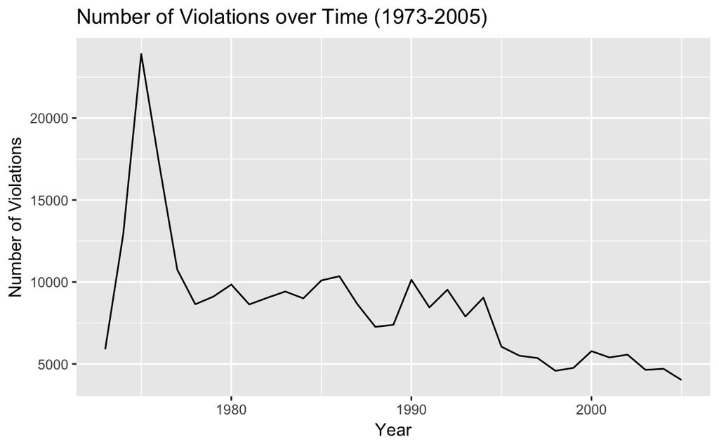

```r
osha %>%
  group_by(year(OPENDT)) %>%
  summarise(violations = sum(VIOLS_), year = mean(year(OPENDT))) %>%
  filter(year >1972, year < 2006) %>%
  ggplot(aes(x = year, y = violations)) +
  geom_line() +
  labs(title = "Number of Violations over Time (1973-2005)", x = "Year", y = "Number of Violations")
```

## Age of the victims of accidents

Age usually plays a role in many work-place accidents. here I plot the distribution of age, differentiated by gender.

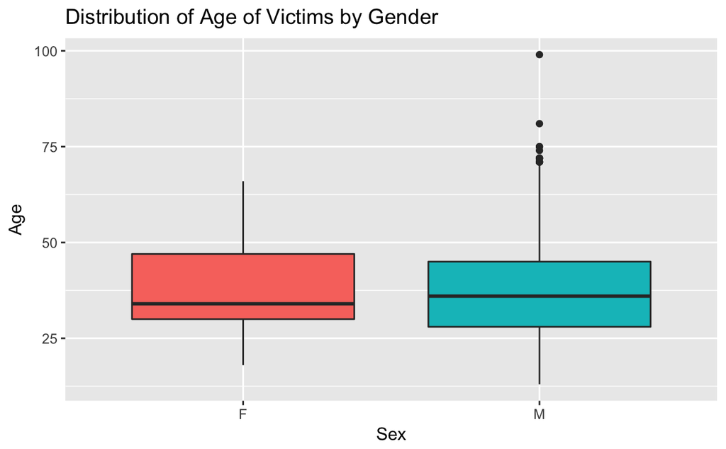

```r
accid %>%
  filter(!is.na(SEX)) %>%
  ggplot(aes(x = SEX, y= AGE, fill = SEX)) +
  geom_boxplot() +
  labs(title = "Distribution of Age of Victims by Gender", x = "Sex", y = "Age") + guides(fill = FALSE)
```

## Nature of the injuries

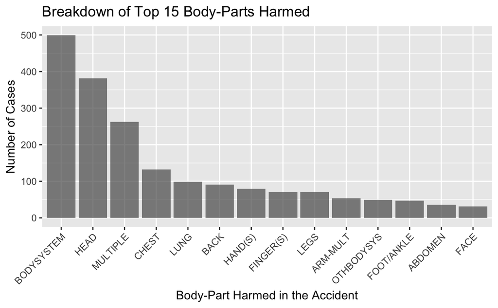

```r
accid %>%
  group_by(BODYPART_NAME) %>%
  summarise(cases = n())  %>%
  arrange(-cases)%>% top_n(n = 15, cases) %>%
  mutate(BODYPART_NAME = factor(BODYPART_NAME, BODYPART_NAME)) %>%
  filter(!is.na(BODYPART_NAME))  %>%
  ggplot(aes( x = BODYPART_NAME, y = cases)) +
  geom_bar(alpha = 0.7, stat = "identity") +
  theme(axis.text.x = element_text(angle = 45, hjust = 1)) +
  labs(title = "Breakdown of Top 15 Body-Parts Harmed", x = "Body-Part Harmed in the Accident", y = "Number of Cases")
```

- I acknowledge that I benefitted from the help of a tutor with whom I work regularly. He reviewed my code and offered some suggestions of improvement. I remain soley responsible of this work.
- I hope you found this as interesting as I did!

# Appendix: Variable Description

The following tables provide information about the variables that remain in the data set after cleaning. For further information, please refer to the original document such as [osha.txt](http://ire.org/media/uploads/files/datalibrary/samplefiles/OSHA%20Workplace%20Safety%20Data/OSHA.txt).

## Description of variables in `osha`

```r
text <- read_lines("layouts/OSHA.txt", skip = 10)
text1 <- gsub("\\t\t\t.*","", text )
text2 <- text1[grepl("\t", text1)]
text3 <- gsub("\\t\t","\t", text2) %>%
  strtrim(100) %>%
  tbl_df %>%
  separate(value, c("variable", "type", "length", "description"), sep = "\t" )
text3$variable <- gsub(" ", "", text3$variable, fixed = TRUE)
text3 <- text3  %>%
  select(variable, description) %>%
  arrange(variable)
osha_descriptions <- text3 %>%
  filter( variable %in% names(osha))
knitr::kable(osha_descriptions, caption = "Description of Variables in `osha`")
```

| variable | description |
| --- | --- |
| ACCID_ | Number of records that should be in ACCID.DBF for this inspection |
| ACTIVITYNO | Unique identifier for each inspection record. |
| ADVNOTICE | Advance notice given |
| ANTCSRVD | Warrant served on subpoena prior to start of inspection |
| CAT_SH | CODES: |
| CATSICGDE | SIC found in the planning guide for the establishment |
| CATSICINSP | SIC inspected if different from primary SIC |
| CLOSECASE | Codes: |
| CLOSEDT | NICAR-converted version of CLOSEDATE |
| CLOSEDT2 | NICAR-converted version of CLOSEDATE2 |
| CONTFLAG | Indicates whether record is a continuation of the previous record (occurs primarily whe |
| DATARQD | 200 log data required per ISA |
| ESTABNAME | Name of establishment |
| FRST_DT | NICAR-converted version of FRSTDENYN |
| FRSTCONDT | NICAR-converted version of FRSTCONTST |
| FRSTDENY | Date of initial denial of entry |
| HELTHCONST | Health construction inspection |
| HELTHMANF | Health manufacturing inspection |
| HELTHMARIT | Health maritime inspection |
| HISTFLAG | Identifies the entry source and era of the record. |
| INSPSCOPE | Inspection scope |
| INSPTYPE | Inspection type |
| INTRVIEWD | Employee(s) interviewed during inspection (state only) |
| JOBTITLE | The job classification of primary compliance officer |
| LSTR_DT | NICAR-converted version of LSTREENTRN |
| LSTREENTR | Date compliance officer re-entered establishment inspection |
| MIGRANT | Inspection of migrant farm worker camp |
| MOD_DATE | NICAR-converted version of OSHA1MOD. |
| NAICS | North American Industry Classification System (See NAICS.DBF) |
| OPENDT | NICAR-converted version of OPENDATE |
| OWNERCODE | Agency code for owner-type = D only (see FDA.dbf) |
| OWNERTYPE | Type of owner |
| PREVACTNO | Unique OSHA number for this inspection |
| PREVCTTYP | The type of the most recent OSHA activity, if any. |
| REPORTID | Unique identification code, one for each federal and state |
| SAFETYMANF | Safety manufacturing inspection |
| SFTYCONST | Safety construction inspection |
| SFTYMARIT | Safety maritime inspection |
| SHPGM | Safety/Health program initiated as result of an |
| SIC | Standard industrial classification (see SIC.DBF) |
| SITEADD | Street address |
| SITECITY | Department of Commerce city code (see SCC.DBF) |
| SITECNTY | Department of Commerce county code (see SCC.DBF) |
| SITEZIP | Zip |
| TOTALVIOLS | Total number of violations issued |
| TOTSERIOUS | Total number of serious, willful, and repeat violations issued |
| UNION | Employees represented by union |
| VIOLS_ | Number of records that should be in VIOLS.DBF for this inspection |
| WALKAROUND | Employee representative present during inspection |
| WHYNOINSP | If no inspection, INSPSCOPE = D |

## Description of variables in `accid`

```r
text <- read_lines("layouts/ACCID.txt", skip = 9)
text1 <- gsub("\\t\t\t\t.*","", text )
text2 <- gsub("\\t\t","\t", text1 )
text2 <- gsub("\\t\t","\t", text2 )
text2 <- gsub("\t$","", text2 )
text3 <- text2[grepl("\t", text2)]
text3 <-  text3 %>% tbl_df %>% separate(value, c("variable", "type", "length", "description"), sep = "\t" ) %>% select(variable, description) %>% arrange(variable)
accid_descriptions <- text3 %>% filter( variable %in% names(accid))
knitr::kable(accid_descriptions, caption = "Description of Variables in `accid`")
```

| variable | description |
| --- | --- |
| ACTIVITYNO | Unique identifier for each inspection record |
| AGE | Age of victim |
| BODYPART | Part of body (see ACC.DBF lookup for codes) |
| DEGREE | Extent of injury |
| HUMAN | Human factor (see ACC.DBF lookup for codes) |
| NATURE | Nature of injury (see ACC.DBF lookup for codes) |
| SEX | Gender of victim |

## Description of variables in `viol`

```r
text <- read_lines("layouts/VIOL.txt", skip = 7)
text1 <- gsub("\\t\t\t\t.*","", text )
text2 <- gsub("\\t\t","\t", text1 )
text2 <- gsub("\\t\t","\t", text2 )
text2 <- gsub("\t$","", text2 )
text3 <- text2[grepl("\t", text2)]
text3 <-  text3 %>% tbl_df %>% separate(value, c("variable", "type", "length", "description"), sep = "\t" ) %>% select(variable, description) %>% arrange(variable)
viol_descriptions <- text3 %>% filter( variable %in% names(viol))
knitr::kable(viol_descriptions, caption = "Description of Variables in `viol`")
```

| variable | description |
| --- | --- |
| ACTIVITYNO | Unique identifier for each inspection record |
| GRAVITY | Indicates the level of potential harm to worker(s), values B, |
| INSTANCES | Number of instances of violation of standard related event |
| NUMEXPOSED | Number of employees exposed to hazard violated |
| VIOLTYPE | Current type of violation |
| VIOLTYPEA | Initial assess violation type |

```r
rm(text, text1, text2, text3)
```